# Exploratory analysis of videogames sales dataset

We load a videogames sales dataset for doing displays, groups and descriptive summaries which can give a intuition about the dataset information. In detail, we want to know:

### First, let’s study the dataset

We load data and show its information:

```r
data <- read.csv("./data/videogames-sales-data.csv")
head(data)
```

|  | Rank | Name | Platform | Year | Genre | Publisher | NA_Sales | EU_Sales | JP_Sales | Other_Sales | Global_Sales |
| --- | --- | --- | --- | --- | --- | --- | --- | --- | --- | --- | --- |
| 1 | 1 | Wii Sports | Wii | 2006 | Sports | Nintendo | 41.49 | 29.02 | 3.77 | 8.46 | 82.74 |
| 2 | 2 | Super Mario Bros. | NES | 1985 | Platform | Nintendo | 29.08 | 3.58 | 6.81 | 0.77 | 40.24 |
| 3 | 3 | Mario Kart Wii | Wii | 2008 | Racing | Nintendo | 15.85 | 12.88 | 3.79 | 3.31 | 35.82 |
| 4 | 4 | Wii Sports Resort | Wii | 2009 | Sports | Nintendo | 15.75 | 11.01 | 3.28 | 2.96 | 33.00 |
| 5 | 5 | Pokemon Red/Pokemon Blue | GB | 1996 | Role-Playing | Nintendo | 11.27 | 8.89 | 10.22 | 1.00 | 31.37 |
| 6 | 6 | Tetris | GB | 1989 | Puzzle | Nintendo | 23.20 | 2.26 | 4.22 | 0.58 | 30.26 |

We are only going to use the data before the year 2017:

```r
data$Year <- ordered(data$Year) # For that, we make the data$Year like ordered factor
data <- data[data$Year < 2017, ] # Data before 2017
max(data$Year) # Check the maximum
```

```
[1] 2016
40 Levels: 1980 < 1981 < 1982 < 1983 < 1984 < 1985 < 1986 < 1987 < 1988 < 1989 < 1990 < 1991 < 1992 < 1993 < 1994 < ... < N/A
```

```r
min(data$Year) # Check the minimum
```

```
[1] 1980
40 Levels: 1980 < 1981 < 1982 < 1983 < 1984 < 1985 < 1986 < 1987 < 1988 < 1989 < 1990 < 1991 < 1992 < 1993 < 1994 < ... < N/A
```

We see the data summary:

```r
summary(data)
```

```
      Rank                                Name          Platform         Year               Genre
 Min.   :    1   Need for Speed: Most Wanted:   12   DS     :2132   2009   :1431   Action      :3252
 1st Qu.: 4136   FIFA 14                    :    9   PS2    :2127   2008   :1428   Sports      :2304
 Median : 8294   LEGO Marvel Super Heroes   :    9   PS3    :1304   2010   :1259   Misc        :1710
 Mean   : 8292   Ratatouille                :    9   Wii    :1290   2007   :1202   Role-Playing:1469
 3rd Qu.:12440   Angry Birds Star Wars      :    8   X360   :1235   2011   :1139   Shooter     :1282
 Max.   :16600   Cars                       :    8   PSP    :1197   2006   :1008   Adventure   :1276
                 (Other)                    :16268   (Other):7038   (Other):8856   (Other)     :5030
                        Publisher        NA_Sales          EU_Sales          JP_Sales         Other_Sales
 Electronic Arts             : 1339   Min.   : 0.0000   Min.   : 0.0000   Min.   : 0.00000   Min.   : 0.00000
 Activision                  :  966   1st Qu.: 0.0000   1st Qu.: 0.0000   1st Qu.: 0.00000   1st Qu.: 0.00000
 Namco Bandai Games          :  928   Median : 0.0800   Median : 0.0200   Median : 0.00000   Median : 0.01000
 Ubisoft                     :  917   Mean   : 0.2655   Mean   : 0.1476   Mean   : 0.07868   Mean   : 0.04834
 Konami Digital Entertainment:  823   3rd Qu.: 0.2400   3rd Qu.: 0.1100   3rd Qu.: 0.04000   3rd Qu.: 0.04000
 THQ                         :  712   Max.   :41.4900   Max.   :29.0200   Max.   :10.22000   Max.   :10.57000
 (Other)                     :10638
  Global_Sales
 Min.   : 0.0100
 1st Qu.: 0.0600
 Median : 0.1700
 Mean   : 0.5403
 3rd Qu.: 0.4800
 Max.   :82.7400
```

### Second, let’s see the correlation of variables of the global sales

We analyze the sales variables, first, we observe what percentage of the global sales represent the local sales:

```r
num_sales <- data[, c("NA_Sales", "EU_Sales", "JP_Sales", "Other_Sales", "Global_Sales")] # We take only the column sales
head(num_sales) # We show it
```

|  | NA_Sales | EU_Sales | JP_Sales | Other_Sales | Global_Sales |
| --- | --- | --- | --- | --- | --- |
| 1 | 41.49 | 29.02 | 3.77 | 8.46 | 82.74 |
| 2 | 29.08 | 3.58 | 6.81 | 0.77 | 40.24 |
| 3 | 15.85 | 12.88 | 3.79 | 3.31 | 35.82 |
| 4 | 15.75 | 11.01 | 3.28 | 2.96 | 33.00 |
| 5 | 11.27 | 8.89 | 10.22 | 1.00 | 31.37 |
| 6 | 23.20 | 2.26 | 4.22 | 0.58 | 30.26 |

```r
apply(X = num_sales, MARGIN = 2, FUN = sum) / sum(num_sales$Global_Sales) * 100 # We calculate the percentage
```

```
    NA_Sales     EU_Sales     JP_Sales  Other_Sales Global_Sales
   49.128687    27.314224    14.560625     8.945445   100.000000
```

It is observed that the global sales are strongly linked to NA > EU > JP. This suppose that the JP sales are weakly linked to the global sales. Let’s see what is the reason:

### Difference in Genre preferences of JP market with respect to Global market

We load the necessary libraries:

```r
library(dplyr)
library(ggplot2)
```

```r
# We get the top genre reveune by year of JP sales
top_genre_year_JP <- data %>%
                        group_by(Year, Genre) %>%
                        summarize(Reveune = sum(JP_Sales)) %>%
                        top_n(1)
# We get the top genre reveune by year of Global sales
top_genre_year_Global <- data %>%
                        group_by(Year, Genre) %>%
                        summarize(Reveune = sum(Global_Sales)) %>%
                        top_n(1)
head(top_genre_year_JP)
```

| Year | Genre | Reveune |
| --- | --- | --- |
| 1980 | Action | 0 |
| 1980 | Fighting | 0 |
| 1980 | Misc | 0 |
| 1980 | Shooter | 0 |
| 1980 | Sports | 0 |
| 1981 | Action | 0 |

```r
head(top_genre_year_Global)
```

| Year | Genre | Reveune |
| --- | --- | --- |
| 1980 | Shooter | 7.07 |
| 1981 | Action | 14.84 |
| 1982 | Puzzle | 10.03 |
| 1983 | Platform | 6.93 |
| 1984 | Shooter | 31.10 |
| 1985 | Platform | 43.17 |

We plot the data of JP and Global sales, for seeing its distribution by genre reveune each year:

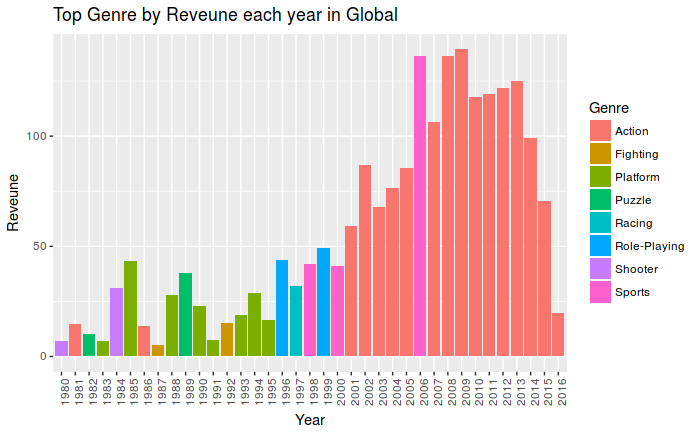

```r
ggplot(top_genre_year_Global, aes(x = Year, y = Reveune, fill = Genre)) +
  geom_bar(stat = "identity") +
  ggtitle("Top Genre by Reveune each year in Global") +
  theme(axis.text.x = element_text(angle = 90))
```

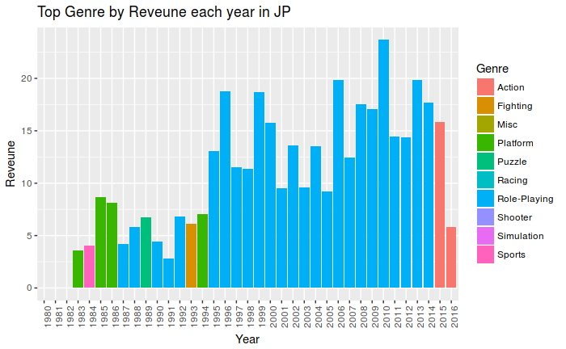

```r
ggplot(top_genre_year_JP, aes(x = Year, y = Reveune, fill = Genre)) +
  geom_bar(stat = "identity") +
  ggtitle("Top Genre by Reveune each year in JP") +
  theme(axis.text.x = element_text(angle = 90))
```

#### Zoom in the concrete markets as for 2008

We take the data after 2008:

```r
zoom_data <- data[data$Year >= 2008, ]
max(zoom_data$Year)
```

```
[1] 2016
40 Levels: 1980 < 1981 < 1982 < 1983 < 1984 < 1985 < 1986 < 1987 < 1988 < 1989 < 1990 < 1991 < 1992 < 1993 < 1994 < ... < N/A
```

```r
min(zoom_data$Year)
```

```
[1] 2008
40 Levels: 1980 < 1981 < 1982 < 1983 < 1984 < 1985 < 1986 < 1987 < 1988 < 1989 < 1990 < 1991 < 1992 < 1993 < 1994 < ... < N/A
```

We group by Genre for each market:

```r
NA_genre <- zoom_data %>%
              group_by(Genre) %>%
              summarize(Reveune = sum(NA_Sales))
EU_genre <- zoom_data %>%
              group_by(Genre) %>%
              summarize(Reveune = sum(EU_Sales))
JP_genre <- zoom_data %>%
              group_by(Genre) %>%
              summarize(Reveune = sum(JP_Sales))
Others_genre <- zoom_data %>%
                  group_by(Genre) %>%
                  summarize(Reveune = sum(Other_Sales))
Global_genre <- zoom_data %>%
                  group_by(Genre) %>%
                  summarize(Reveune = sum(Global_Sales))
head(NA_genre)
```

| Genre | Reveune |
| --- | --- |
| Action | 431.78 |
| Adventure | 43.79 |
| Fighting | 74.73 |
| Misc | 213.99 |
| Platform | 93.31 |
| Puzzle | 28.91 |

```r
head(EU_genre)
```

| Genre | Reveune |
| --- | --- |
| Action | 314.96 |
| Adventure | 30.27 |
| Fighting | 35.63 |
| Misc | 109.67 |
| Platform | 61.05 |
| Puzzle | 17.55 |

```r
head(JP_genre)
```

| Genre | Reveune |
| --- | --- |
| Action | 88.68 |
| Adventure | 23.13 |
| Fighting | 22.93 |
| Misc | 36.98 |
| Platform | 22.95 |
| Puzzle | 5.97 |

```r
head(Others_genre)
```

| Genre | Reveune |
| --- | --- |
| Action | 113.63 |
| Adventure | 9.40 |
| Fighting | 16.37 |
| Misc | 41.26 |
| Platform | 20.15 |
| Puzzle | 4.57 |

```r
head(Global_genre)
```

| Genre | Reveune |
| --- | --- |
| Action | 949.24 |
| Adventure | 106.75 |
| Fighting | 149.61 |
| Misc | 402.02 |
| Platform | 197.48 |
| Puzzle | 57.14 |

Now, we plot the calculated data:

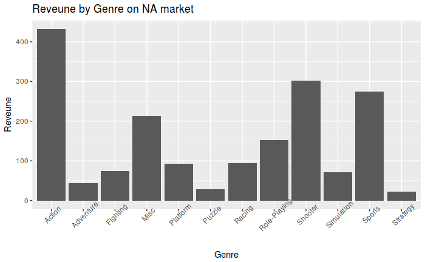

```r
ggplot(NA_genre, aes(x = Genre, y = Reveune)) +
  geom_bar(stat = "identity") +
  ggtitle("Reveune by Genre on NA market") +
  theme(axis.text.x = element_text(angle = 45))
```

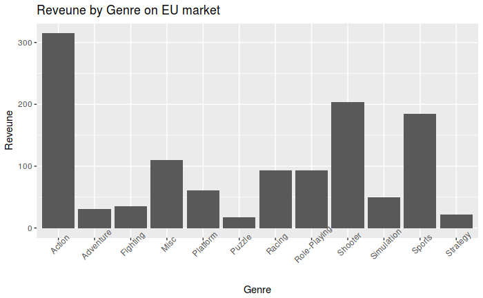

```r
ggplot(EU_genre, aes(x = Genre, y = Reveune)) +
  geom_bar(stat = "identity") +
  ggtitle("Reveune by Genre on EU market") +
  theme(axis.text.x = element_text(angle = 45))
```

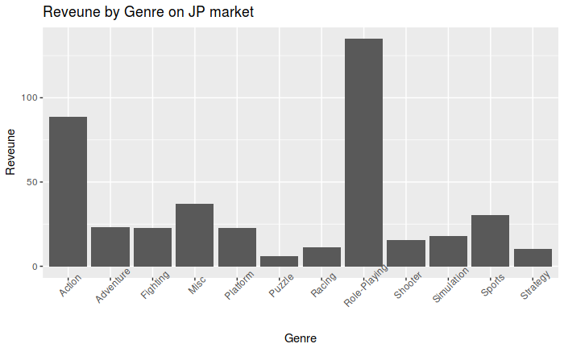

```r
ggplot(JP_genre, aes(x = Genre, y = Reveune)) +
  geom_bar(stat = "identity") +
  ggtitle("Reveune by Genre on JP market") +
  theme(axis.text.x = element_text(angle = 45))
```

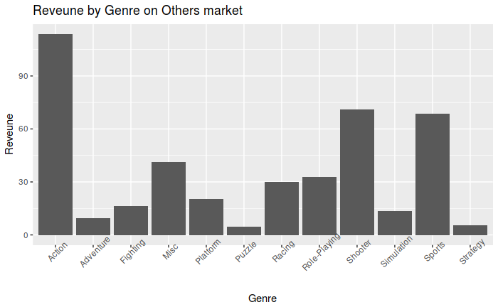

```r
ggplot(Others_genre, aes(x = Genre, y = Reveune)) +
  geom_bar(stat = "identity") +
  ggtitle("Reveune by Genre on Others market") +
  theme(axis.text.x = element_text(angle = 45))
```

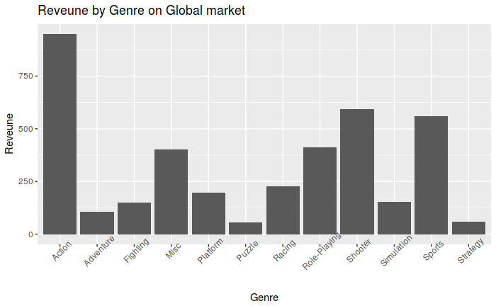

```r
ggplot(Global_genre, aes(x = Genre, y = Reveune)) +
  geom_bar(stat = "identity") +
  ggtitle("Reveune by Genre on Global market") +
  theme(axis.text.x = element_text(angle = 45))
```

We can observe that in all markets (excepting JP), the leader genre is Action, like we have observed before.

### Third, let’s see the sales evolution of the markets over time

We get the all sales by year for each market:

```r
NA_evolution <- data %>%
                group_by(Year) %>%
                summarize(Reveune = sum(NA_Sales))
EU_evolution <- data %>%
                group_by(Year) %>%
                summarize(Reveune = sum(EU_Sales))
JP_evolution <- data %>%
                group_by(Year) %>%
                summarize(Reveune = sum(JP_Sales))
Other_evolution <- data %>%
                group_by(Year) %>%
                summarize(Reveune = sum(Other_Sales))
Global_evolution <- data %>%
                group_by(Year) %>%
                summarize(Reveune = sum(Global_Sales))
sales_evolution <- data.frame(Year = c(1980:2016), NA_Sales = NA_evolution$Reveune, EU_Sales = EU_evolution$Reveune, JP_Sales = JP_evolution$Reveune, Other_Sales = Other_evolution$Reveune, Global_Sales = Global_evolution$Reveune)
sales_evolution
```

| Year | NA_Sales | EU_Sales | JP_Sales | Other_Sales | Global_Sales |
| --- | --- | --- | --- | --- | --- |
| 1980 | 10.59 | 0.67 | 0.00 | 0.12 | 11.38 |
| 1981 | 33.40 | 1.96 | 0.00 | 0.32 | 35.77 |
| 1982 | 26.92 | 1.65 | 0.00 | 0.31 | 28.86 |
| 1983 | 7.76 | 0.80 | 8.10 | 0.14 | 16.79 |
| 1984 | 33.28 | 2.10 | 14.27 | 0.70 | 50.36 |
| 1985 | 33.73 | 4.74 | 14.56 | 0.92 | 53.94 |
| 1986 | 12.50 | 2.84 | 19.81 | 1.93 | 37.07 |
| 1987 | 8.46 | 1.41 | 11.63 | 0.20 | 21.74 |
| 1988 | 23.87 | 6.59 | 15.76 | 0.99 | 47.22 |
| 1989 | 45.15 | 8.44 | 18.36 | 1.50 | 73.45 |

[output cut: 27 more lines]

We plot the sales evolution:

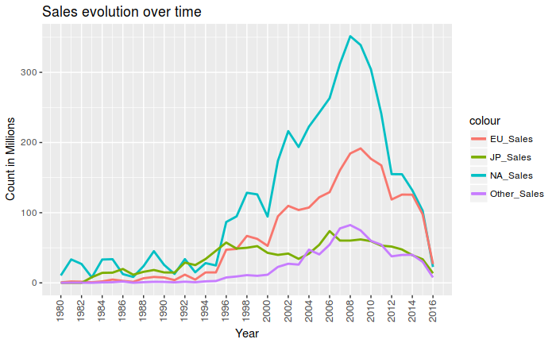

```r
ggplot(sales_evolution, aes(x = Year)) +
  geom_line(aes(y = NA_evolution$Reveune, colour = "NA_Sales"), size=1) +
  geom_line(aes(y = EU_evolution$Reveune, colour = "EU_Sales"), size=1) +
  geom_line(aes(y = JP_evolution$Reveune, colour = "JP_Sales"), size=1) +
  geom_line(aes(y = Other_evolution$Reveune, colour = "Other_Sales"), size=1) +
  ylab('Count in Millions') +
  scale_x_continuous(breaks = scales::pretty_breaks(n = 20))+
  ggtitle("Sales evolution over time") +
    theme(axis.text.x = element_text(angle = 90, size = 10, vjust = 0.4))
```

It is observed that between the years 2000 and 2010, the NA sales dominated and that as of 2008 (coindice with the global crisis) this domination decreases. Also, we can observe that the NA sales are strongly linked with teh Global sales, like we have can observe in the begining of this notebook.